# US Gun Violence and Census Data from California 2015

Assignment 3, MATH2349, Semester 1, 2018

Alistair Grevis-James (s3644119) and Christopher Kaias (s3090801)

### Executive Summary

The required libraries were imported into the RStudio interactive development environment, followed by the .csv files “gun-violence-data” and “American Census Data 2015” as `gvd` and `acs2015`, respectively [^1][^2]. These data sets were then checked for tidiness (`gvd` untidy, `acs2015` tidy), dimensions (`gvd` 239677 obs. of 29 variables, `acs2015` 3220 obs. of 37 variables), NA count and attribute classes (see summary tables below).  
The `gvd` dataset failed to conform to the “tidy data” principles. Most notably, the attributes prefixed “participant_” contained multiple values per cell, delimited by a combination of [:digit:], :: and/or ||. In order to be computationally efficient, it was decided to first subset `gvd` before cleaning the aforementioned “participant_” attributes. As the `acs2015` dataset contained values from only the 2015 American (US) Census, the first subset involved filtering values of the year 2015 from the `gvd` dataset.  
This was achieved using the `as.logical()` and `year()` functions, creating and applying a boolean vector to `gvd` to create the dataset `gvd2015`. This methodology enabled us to retain the native date format YYYY-MM-DD. The `gvd2015` was then filtered for values which satisfied the condition `state == “California”`, giving `gvd2015_keep_cali`. A custom function was written and employed to scour through the `participant_age` column of `gvd2015`. This resulted in capturing age counts of incident participants by binning them into approximately 5-years bin intervals. The `participant, _gender, _status, _type` columns were then also all stripped of string prefix values and binned. The resultant `killed_count` and `injured_count` matched perfectly the original `n_killed` and `n_injured` attributes, indicating an extremely precise processing methodology. It was determined that the `incident_url` column of `gvd2015_keep_cali` could be dropped, as the URL prefix in every case matched the unique incident ID. The `acs2015` dataset was then filtered for values from the state of California. Following this step, an inner join was performed between the Gun Violence and American (US) Census datasets.  
The joined dataset was checked for NA values, followed by conversion to long format for plotting and value distribution analysis. The data was transformed and checked and cleaned for outliers.

### Required packages

```r
#The following packages were used whilst completing the report (with annotation)
library(readr) # Used to import .csv files
library(dplyr) # Section Y
library(stringr) # Section Z
library(knitr) # Section X
library(tidyr)
library(lubridate)
library(kableExtra)
library(outliers)
library(ggplot2)
#xlsx #readxl #foreign #gdata #rvest #dplyr  #deductive #validate #Hmisc
#MVN #infotheo #MASS #caret #MLR #ggplot #base R functions
```

### Importing the Data

The first dataset, ‘Gun Violence Data - A Comprehensive Record of Over 260k US Gun Violence Incidents from 2013-2018’, was compiled by James Ko and made available on kaggle.com. This dataset contains all recorded gun violence incidents in the US between January 2013 and March 2018 (inclusive).  
The second dataset, ‘US Census Demographic Data Demographic and Economic Data for Tracts and Counties’, was collected by the US Census Bureau and made available on kaggle.com. This dataset contains all census data from the 2015 Federal US census.  
The `readr` function was used to import the data as shown below.

```r
gvdZip <- "gun-violence-data.csv.zip"
outDir<-"/Users/alistairgj/Documents/GitHub" # Change output directory for unzipped .csv file as needed
unzip(gvdZip, exdir=outDir)
setwd("/Users/alistairgj/Documents/GitHub")
gvd <- read.csv("gun-violence-data.csv") # Importing Gun Violence Data
setwd("/Users/alistairgj/Documents/GitHub/MATH2349_Assignment3V2")
acs2015 <- read.csv("acs2015_county_data.csv") # Importing American (US) Census Data 2015
```

### Checking the Data

Two custom output table was created to check `gvd` & `acs2015`. These results are summarized below.

| Feature | gvd | acs2015 |
| --- | --- | --- |
| Observations | 239677 | 3220 |
| Attributes | 29 | 37 |
| Tidy | No | Yes |
| Format | Wide | Wide |
| Unique Ref | Yes - IncidentID | Yes - CensusID |
| Incorrect Class | Attribute 1, 5, 8:14, 16, 19 | Attribute 1 |
| Contains NA | Attribute 11, 15, 17, 18, 28, 29 | Attribute 14, 15, 19 |

```r
data.frame(AttNo = c(1:29), Attribute = names(gvd), Class = sapply(gvd, class),
           gvd_incident486623 = sapply(gvd[84,], function(x) paste0(head(x),  collapse = ", ")),
           NA_Count = sapply(gvd, function(y) sum(length(which(is.na(y))))),
           row.names = NULL) %>% kable() %>% kable_styling(bootstrap_options = c("striped", "hover", "condensed"),  font_size = 11) %>% scroll_box(height = "200px")
```

| AttNo | Attribute | Class | gvd_incident486623 | NA_Count |
| --- | --- | --- | --- | --- |
| 1 | incident_id | integer | 486623 | 0 |
| 2 | date | factor | 2013-05-23 | 0 |
| 3 | state | factor | Tennessee | 0 |
| 4 | city_or_county | factor | Bean Station | 0 |
| 5 | address | factor | 1034 Main Street | 0 |
| 6 | n_killed | integer | 2 | 0 |
| 7 | n_injured | integer | 2 | 0 |
| 8 | incident_url | factor | http://www.gunviolencearchive.org/incident/486623 | 0 |
| 9 | source_url | factor | http://legacy.wbir.com/story/news/local/hamblen-jefferson-cocke-greene/2014/10/01/developing-pharmacy-shooting-suspect-to-make-plea-deal/16526831/ | 0 |
| 10 | incident_url_fields_missing | factor | False | 0 |
| 11 | congressional_district | integer | 2 | 11944 |
| 12 | gun_stolen | factor | 0::Unknown | 0 |
| 13 | gun_type | factor | 0::Unknown | 0 |
| 14 | incident_characteristics | factor | Shot - Wounded/Injured\|\|Shot - Dead (murder, accidental, suicide)\|\|Mass Shooting (4+ victims injured or killed excluding the subject/suspect/perpetrator, one location)\|\|Armed robbery with injury… | 0 |
| 15 | latitude | numeric | 36.3474 | 7923 |
| 16 | location_description | factor | Down Home Pharmacy | 0 |
| 17 | longitude | numeric | -83.2849 | 7923 |
| 18 | n_guns_involved | integer | 1 | 99451 |
| 19 | notes | factor | ms; 2 dead; 2 wounded. Pharmacy robbery by ex cop. He was sentenced to life in prison without the possibility of parole. | 0 |
| 20 | participant_age | factor | 1::72\|\|2::45\|\|4::37 | 0 |
| 21 | participant_age_group | factor | 0::Adult 18+\|\|1::Adult 18+\|\|2::Adult 18+\|\|3::Adult 18+\|\|4::Adult 18+ | 0 |
| 22 | participant_gender | factor | 0::Male\|\|1::Male\|\|2::Female\|\|3::Female\|\|4::Male | 0 |
| 23 | participant_name | factor | 0::Stephen Lovell\|\|1::Richard Alexander Sommerville\|\|2::Alexia Gail Wilson\|\|3::Janet Cliff\|\|4::Jason Brian Holt | 0 |
| 24 | participant_relationship | factor | 4::Armed Robbery | 0 |
| 25 | participant_status | factor | 0::Killed\|\|1::Killed\|\|2::Injured\|\|3::Injured\|\|4::Unharmed, Arrested | 0 |
| 26 | participant_type | factor | 0::Victim\|\|1::Victim\|\|2::Victim\|\|3::Victim\|\|4::Subject-Suspect | 0 |
| 27 | sources | factor | http://www.dailymail.co.uk/news/article-2330162/Former-police-officer-hunt-pain-pills-shoots-dead-pharmacy-owner-customer-robbery.html?ito=feeds-newsxml\|\|http://legacy.wbir.com/story/news/local/hamb… | 0 |
| 28 | state_house_district | integer | 35 | 38772 |
| 29 | state_senate_district | integer | 8 | 32335 |

```r
data.frame(AttNo = c(1:37), Attribute = names(acs2015), Class = sapply(acs2015, class),
           acs2015 = sapply(acs2015, function(x) paste(head(x),  collapse = ", ")),
           NA_Count = sapply(acs2015, function(y) sum(length(which(is.na(y))))),
           row.names = NULL) %>% kable() %>% kable_styling(bootstrap_options = c("striped", "hover", "condensed"),
                                                           font_size = 11) %>% scroll_box(height = "200px")
```

| AttNo | Attribute | Class | acs2015 | NA_Count |
| --- | --- | --- | --- | --- |
| 1 | CensusId | integer | 1001, 1003, 1005, 1007, 1009, 1011 | 0 |
| 2 | State | factor | Alabama, Alabama, Alabama, Alabama, Alabama, Alabama | 0 |
| 3 | County | factor | Autauga, Baldwin, Barbour, Bibb, Blount, Bullock | 0 |
| 4 | TotalPop | integer | 55221, 195121, 26932, 22604, 57710, 10678 | 0 |
| 5 | Men | integer | 26745, 95314, 14497, 12073, 28512, 5660 | 0 |
| 6 | Women | integer | 28476, 99807, 12435, 10531, 29198, 5018 | 0 |
| 7 | Hispanic | numeric | 2.6, 4.5, 4.6, 2.2, 8.6, 4.4 | 0 |
| 8 | White | numeric | 75.8, 83.1, 46.2, 74.5, 87.9, 22.2 | 0 |
| 9 | Black | numeric | 18.5, 9.5, 46.7, 21.4, 1.5, 70.7 | 0 |
| 10 | Native | numeric | 0.4, 0.6, 0.2, 0.4, 0.3, 1.2 | 0 |
| 11 | Asian | numeric | 1, 0.7, 0.4, 0.1, 0.1, 0.2 | 0 |
| 12 | Pacific | numeric | 0, 0, 0, 0, 0, 0 | 0 |
| 13 | Citizen | integer | 40725, 147695, 20714, 17495, 42345, 8057 | 0 |
| 14 | Income | numeric | 51281, 50254, 32964, 38678, 45813, 31938 | 1 |
| 15 | IncomeErr | numeric | 2391, 1263, 2973, 3995, 3141, 5884 | 1 |
| 16 | IncomePerCap | integer | 24974, 27317, 16824, 18431, 20532, 17580 | 0 |
| 17 | IncomePerCapErr | integer | 1080, 711, 798, 1618, 708, 2055 | 0 |
| 18 | Poverty | numeric | 12.9, 13.4, 26.7, 16.8, 16.7, 24.6 | 0 |
| 19 | ChildPoverty | numeric | 18.6, 19.2, 45.3, 27.9, 27.2, 38.4 | 1 |
| 20 | Professional | numeric | 33.2, 33.1, 26.8, 21.5, 28.5, 18.8 | 0 |
| 21 | Service | numeric | 17, 17.7, 16.1, 17.9, 14.1, 15 | 0 |
| 22 | Office | numeric | 24.2, 27.1, 23.1, 17.8, 23.9, 19.7 | 0 |
| 23 | Construction | numeric | 8.6, 10.8, 10.8, 19, 13.5, 20.1 | 0 |
| 24 | Production | numeric | 17.1, 11.2, 23.1, 23.7, 19.9, 26.4 | 0 |
| 25 | Drive | numeric | 87.5, 84.7, 83.8, 83.2, 84.9, 74.9 | 0 |
| 26 | Carpool | numeric | 8.8, 8.8, 10.9, 13.5, 11.2, 14.9 | 0 |
| 27 | Transit | numeric | 0.1, 0.1, 0.4, 0.5, 0.4, 0.7 | 0 |
| 28 | Walk | numeric | 0.5, 1, 1.8, 0.6, 0.9, 5 | 0 |
| 29 | OtherTransp | numeric | 1.3, 1.4, 1.5, 1.5, 0.4, 1.7 | 0 |
| 30 | WorkAtHome | numeric | 1.8, 3.9, 1.6, 0.7, 2.3, 2.8 | 0 |
| 31 | MeanCommute | numeric | 26.5, 26.4, 24.1, 28.8, 34.9, 27.5 | 0 |
| 32 | Employed | integer | 23986, 85953, 8597, 8294, 22189, 3865 | 0 |
| 33 | PrivateWork | numeric | 73.6, 81.5, 71.8, 76.8, 82, 79.5 | 0 |
| 34 | PublicWork | numeric | 20.9, 12.3, 20.8, 16.1, 13.5, 15.1 | 0 |
| 35 | SelfEmployed | numeric | 5.5, 5.8, 7.3, 6.7, 4.2, 5.4 | 0 |
| 36 | FamilyWork | numeric | 0, 0.4, 0.1, 0.4, 0.4, 0 | 0 |
| 37 | Unemployment | numeric | 7.6, 7.5, 17.6, 8.3, 7.7, 18 | 0 |

The `length()` & `unique()` functions were used to determine if `gvd$incident_id` and `acs2015$CensusId` contained only unique values. In each case the number of values was equal to the number of observations. Thus `incident_id` and `CensusId` may be used as observation identifiers if required.

```r
length(unique(gvd$incident_id)) # Checking the number of unique values for incident_id
```

```
## [1] 239677
```

```r
length(unique(acs2015$CensusId)) # Checking the number of unique values for CensusId
```

```
## [1] 3220
```

Based on the output of the above `gvd` summary table (`data.frame(...`), the `participant_age` and `participant_gender` were explored to better understand their values. It was noted that these cells store multiple, discrete instances of data. The [:digit:] at the start of each value is presumably used to track the values accross from one `participant_` attribute to the next. The first observation below contains only one age value, with four participant values. One avenue for addressing these inconsistencies could involve performing counts for each delimited value. However this is beyond the scope of the current analysis and so this particulat inconsistency will be ignored.

```r
gvd %>% select(participant_age, participant_gender) %>% head(n=8) %>%
  kable() %>% kable_styling(bootstrap_options = c("striped", "hover", "condensed"),  font_size = 11)
```

| participant_age | participant_gender |
| --- | --- |
| 0::20 | 0::Male\|\|1::Male\|\|3::Male\|\|4::Female |
| 0::20 | 0::Male |
| 0::25\|\|1::31\|\|2::33\|\|3::34\|\|4::33 | 0::Male\|\|1::Male\|\|2::Male\|\|3::Male\|\|4::Male |
| 0::29\|\|1::33\|\|2::56\|\|3::33 | 0::Female\|\|1::Male\|\|2::Male\|\|3::Male |
| 0::18\|\|1::46\|\|2::14\|\|3::47 | 0::Female\|\|1::Male\|\|2::Male\|\|3::Female |
| 0::23\|\|1::23\|\|2::33\|\|3::55 | 0::Female\|\|1::Female\|\|2::Female\|\|3::Female\|\|4::Male\|\|5::Male |
| 0::51\|\|1::40\|\|2::9\|\|3::5\|\|4::2\|\|5::15 | 0::Male\|\|1::Female\|\|2::Male\|\|3::Female\|\|4::Female\|\|5::Male |
|  | 0::Male\|\|1::Male\|\|2::Male\|\|3::Male\|\|4::Male |

### Filtering GVD for Year 2015

```r
gvd$date <- as.Date(gvd$date) # Converting the gvd$date column and applying to the gvd dataset
str(gvd$date) # Checking the conversion of gvd$date
```

```
##  Date[1:239677], format: "2013-01-01" "2013-01-01" "2013-01-01" "2013-01-05" "2013-01-07" ...
```

```r
year2015_boolean <- as.logical(year(gvd$date) == "2015") #Creating a year 2015 true/false vector
summary(year2015_boolean) # Checking the vector results
```

```
##    Mode   FALSE    TRUE
## logical  186098   53579
```

```r
gvd2015 <- gvd[year2015_boolean,] # Applying the True/False Vector to filter gvd
```

```r
summary(gvd2015$date) # Confirming only 2015 data is present
```

```
##         Min.      1st Qu.       Median         Mean      3rd Qu.
## "2015-01-01" "2015-04-14" "2015-07-09" "2015-07-06" "2015-09-29"
##         Max.
## "2015-12-31"
```

The DS `gvd2015` is now prepared. As an aside, the first methodology used for extracting YYYY = 2015 value from `gvd$date` relied on conversion of `gvd$date` to contain year only (`gvd$date <- format.Date(gvd$date, format="%Y")`), this was then filtered for values of 2015 (`gvd$date_year <- filter(gvd, date_year == "2015")`). This methodolgy was abandoned, as it unnecessarily stripped out the month and day data from `gvd$date`. The applied method is no more complex but retains more information.

### Filtering for California

The values of `gvd2015$state` were aggregated for comparison (below). The output enables us to determine the number of `city_or_county` in each State, as defined during the composition of the Gun Violence Dataset. For the subsequent analysis, the State of California was selected. This was based on an assumption it would have a large range of discrete and continuous values in the corresponding Census dataset (for example both extremely poor and rich socioeconomic areas). Also note that the methodology outlined below could be applied to any of the states in the `gvd` dataset, so California will act as a proof of concept.

```r
aggregate(city_or_county ~ state, gvd2015, function(x) length(unique(x))) %>%
  kable() %>% kable_styling(bootstrap_options = c("striped", "hover", "condensed"),  font_size = 11) %>%
  row_spec(5, bold = T, background = "lightskyblue") %>%
  scroll_box(height = "200px")
```

| state | city_or_county |
| --- | --- |
| Alabama | 212 |
| Alaska | 63 |
| Arizona | 67 |
| Arkansas | 116 |
| California | 502 |
| Colorado | 105 |
| Connecticut | 84 |
| Delaware | 36 |
| District of Columbia | 4 |
| Florida | 374 |
| Georgia | 313 |
| Hawaii | 28 |
| Idaho | 59 |
| Illinois | 237 |
| Indiana | 164 |
| Iowa | 88 |
| Kansas | 76 |
| Kentucky | 213 |
| Louisiana | 167 |
| Maine | 120 |
| Maryland | 132 |
| Massachusetts | 160 |
| Michigan | 230 |
| Minnesota | 126 |
| Mississippi | 158 |
| Missouri | 218 |
| Montana | 50 |
| Nebraska | 39 |
| Nevada | 34 |
| New Hampshire | 68 |
| New Jersey | 167 |
| New Mexico | 69 |
| New York | 423 |
| North Carolina | 348 |
| North Dakota | 32 |
| Ohio | 306 |
| Oklahoma | 147 |
| Oregon | 120 |
| Pennsylvania | 355 |
| Rhode Island | 23 |
| South Carolina | 247 |
| South Dakota | 35 |
| Tennessee | 208 |
| Texas | 389 |
| Utah | 84 |
| Vermont | 61 |
| Virginia | 213 |
| Washington | 157 |
| West Virginia | 119 |
| Wisconsin | 196 |
| Wyoming | 28 |

```r
gvd2015_keep_cali <- filter(gvd2015, state == "California") # Creating the new dataset
```

```r
aggregate(city_or_county ~ state, gvd2015_keep_cali, function(x) length(unique(x))) %>%
  kable() %>% kable_styling(bootstrap_options = c("striped", "hover", "condensed"),  font_size = 11) %>%
  row_spec(1, bold = T, background = "lightskyblue") # Check the new dataset
```

| state | city_or_county |
| --- | --- |
| California | 502 |

### GVD 2015 California DS

During data exploration it was determined the following attributes will add no futher value to this analysis and will be dropped.

| Attribute | Explanation / Justification |
| --- | --- |
| `address` | This level of extremely fine detail is not required |
| `source_url` | This can be found online the other URL `incident_url` |
| `incident_url_fields_missing` | This is a boolean attribute which can be checked with filtering |
| `incident_characteristics` | These strings are extremely varied in content |
| `location_description` | These strings are extremely varied in content |
| `notes` | These strings are extremely varied in content & contain no information of value for us |
| `participant_age_group` | We can determine this from `participant_age` |
| `participant_name` | This level of extremely fine detail is not required |
| `sources` | We have source information from `incident_url` |

The desired columns were selected back into `gvd2015_keep_cali`, which was then checked in the table below. The attributes `congressional_district`, `state_house_district` & `state_sentate_district` were converted into factors and the dimensions of the new `gvd2015_keep_cali` were checked.

```r
gvd2015_keep_cali <- select(gvd2015_keep_cali, incident_id, date, state, city_or_county, n_killed, n_injured, incident_url, congressional_district, latitude, longitude, n_guns_involved, participant_age, participant_gender, participant_status, participant_type, state_house_district, state_senate_district)
```

```r
data.frame(Attribute = names(gvd2015_keep_cali), Class = sapply(gvd2015_keep_cali, class),
           gvd_incident274168 = sapply(gvd2015_keep_cali[53,], function(x) paste0(head(x),  collapse = ", ")),
           NA_Count = sapply(gvd2015_keep_cali, function(y) sum(length(which(is.na(y))))),
           row.names = NULL) %>% kable() %>% kable_styling(bootstrap_options = c("striped", "hover", "condensed"),
                                                           font_size = 11) %>% scroll_box(height = "200px")
```

| Attribute | Class | gvd_incident274168 | NA_Count |
| --- | --- | --- | --- |
| incident_id | integer | 274386 | 0 |
| date | Date | 2015-01-05 | 0 |
| state | factor | California | 0 |
| city_or_county | factor | Selma | 0 |
| n_killed | integer | 3 | 0 |
| n_injured | integer | 0 | 0 |
| incident_url | factor | http://www.gunviolencearchive.org/incident/274386 | 0 |
| congressional_district | integer | 21 | 23 |
| latitude | numeric | 36.5658 | 19 |
| longitude | numeric | -119.621 | 19 |
| n_guns_involved | integer | 1 | 1976 |
| participant_age | factor | 0::36 | 0 |
| participant_gender | factor | 0::Female\|\|1::Female\|\|2::Male | 0 |
| participant_status | factor | 0::Killed\|\|1::Killed\|\|2::Killed | 0 |
| participant_type | factor | 0::Victim\|\|1::Victim\|\|2::Subject-Suspect | 0 |
| state_house_district | integer | 31 | 24 |
| state_senate_district | integer | 14 | 23 |

```r
gvd2015_keep_cali$congressional_district <- as.factor(gvd2015_keep_cali$congressional_district)
gvd2015_keep_cali$state_house_district <- as.factor(gvd2015_keep_cali$state_house_district)
gvd2015_keep_cali$state_senate_district <- as.factor(gvd2015_keep_cali$state_senate_district)
```

```r
dim(gvd2015_keep_cali)
```

```
## [1] 3234   17
```

### Incident_URL Attribute

The attribute `incident_url` was compared with `incident_id`. Using string manipulation, the suffix `http://www.gunviolencearchive.org/incident/` was removed from all values in the `incident_url`. The resultant `_url` column and the original `_id` column were converted into vectors (_id = a, _url = b). The vectors a and b were compared, with a delta value of 0. The `_url` attribute is therefore deemed unnecessary and will be dropped.

```r
gvd2015_keep_cali$incident_url <-  gvd2015_keep_cali$incident_url %>%
  str_replace_all("http://www.gunviolencearchive.org/incident/", "") # Cleaving off the suffix
gvd2015_keep_cali$incident_url <- as.integer(gvd2015_keep_cali$incident_url)
```

```r
# Create two vectors
a <- as.vector(gvd2015_keep_cali$incident_id)
b <- as.vector(gvd2015_keep_cali$incident_url)
a[!(a %in% b)]
```

```
## integer(0)
```

### n_gun_involved Attribute

This attribute contained approximately 60% NA values (Var1(1) = NA) and was dropped.

```r
table(sapply(gvd2015_keep_cali$n_guns_involved, function(y) sum(length(which(is.na(y)))))) %>% kable() %>% kable_styling(bootstrap_options = c("striped", "hover", "condensed"),  font_size = 11)
```

| Var1 | Freq |
| --- | --- |
| 0 | 1258 |
| 1 | 1976 |

### participant_age Attribute

The following function was constructed to iterate through the integer values of the participant_age column and bin the values using a +1 count. The resultant binned counts were spread over 15 new attributes.

```r
gvd2015_keep_cali$matches <- str_match_all(gvd2015_keep_cali$participant_age, "\\d+::(\\d+)")
ages = c(c(0,15)) # First age range is under 15s
for (i in seq(16, 76, 5)) # The other age ranges are every 5 years
{
  ages <- c(ages, c(i, i+4))
}
ages <- c(ages, c(81,100)) # The last age range is 81 plus
for (i in seq(1,length(ages)-1, 2)) # Each pair of ages in the age ranges
{
  # Construct the column using apply
  # Paste here concatenates the string for the column name
  gvd2015_keep_cali[paste("age", ages[i],ages[i+1], sep="_")] <- apply(gvd2015_keep_cali, 1, function(row) {
    cnt <- 0 # Count of ages in current range starts at 0
    for (x in row$matches) # Iterate through the matches we parsed out
    { if (!grepl(":", x, fixed = TRUE)) # If the match does not contain a : then it is the match group rather than the match
      { age <- as.integer(x) # so convert age as string to integer
          if (age >= ages[i] && age <= ages[i+1]) # and check if age falls within age range for the current column
        { cnt <- cnt + 1 }
      }
    }
    as.integer(cnt)
  })
}
```

### participant_gender Attribute

The characters `,[:space:]`, `::`, `[:digit:]` & `||` were stripped from the `participant_gender` as seen below. A new char value was subsequently created, `participant_gender_unique_check`. This value was then checked for unique characters, which yielded only blank (“”), Female and Male. Two `str_count` functions were then used to generate count columns for gender, these were named `male_count` and `female_count`. The column `participant_gender` will be later dropped.

```r
gvd2015_keep_cali$participant_gender <-  gvd2015_keep_cali$participant_gender %>%
  str_replace_all(",[:space:]", "") %>% #Remove comma & whitespace
  str_replace_all("::", "") %>%
  str_replace_all("[:digit:]", " ") %>%
  str_replace_all("\\||", "")
```

```r
participant_gender_unique_check <- as.character(gvd2015_keep_cali[,c("participant_gender")])
ul <- unlist(strsplit(participant_gender_unique_check, " "))
unique(ul)
```

```
## [1] ""       "Male"   "Female"
```

```r
gvd2015_keep_cali$male_count <- str_count(gvd2015_keep_cali$participant_gender, pattern = "Male") # Stringr
gvd2015_keep_cali$female_count <- str_count(gvd2015_keep_cali$participant_gender, pattern = "Female") # Stringr
```

### Participant_status Attribute

The characters `,[:space:]`, `::`, `[:digit:]` & `||` were stripped from the `participant_status` in the same manner as for `participant_gender`. The same methodology was then used to generate counts (`unlist`, `strsplit`, `unique`) for the `participant_status` values, giving the following:

```r
participant_status_unique_check <- as.character(gvd2015_keep_cali[,c("participant_status")])
ul <- unlist(strsplit(participant_status_unique_check, " "))
unique(ul)
```

```
##  [1] ""                        "Killed"
##  [3] "Injured"                 "UnharmedArrested"
##  [5] "InjuredUnharmedArrested" "Arrested"
##  [7] "Unharmed"                "InjuredArrested"
##  [9] "KilledArrested"          "KilledUnharmed"
## [11] "KilledUnharmedArrested"
```

```r
InjuredUnharmedArrested <- grepl("InjuredUnharmedArrested", gvd2015_keep_cali$participant_status)
gvd2015_keep_cali[InjuredUnharmedArrested,c(1,14)]
```

|  | incident_id | participant_status |
| --- | --- | --- |
| 7 | 273316 | Killed UnharmedArrested UnharmedArrested InjuredUnharmedArrested |

The values were all checked as described above and updated as follows:

| OriginalValue | Explanation / Justification | UpdatedValue |
| --- | --- | --- |
| `InjuredUnharmedArrested` | This value was created as the reporting of an incident is updated | `InjuredArrested` |
| `KilledInjured` | This value was created when a person who was initially injured later dies | `Killed` |
| `KilledArrested` | This value was created when a person who was mortally wounded, arrested and later dies | `Killed` |
| `KilledUnharmed` | This value was created as the reporting of an incident is updated | `Killed` |
| `InjuredUnharmed` | This value was created as the reporting of an incident is updated | `Injured` |
| `KilledUnharmedArrested` | This value was created as the reporting of an incident is updated | `Killed` |

```r
gvd2015_keep_cali$participant_status <- str_replace_all(gvd2015_keep_cali$participant_status, "InjuredUnharmedArrested", "InjuredArrested")
gvd2015_keep_cali$participant_status <- str_replace_all(gvd2015_keep_cali$participant_status, "KilledInjured", "Killed")
gvd2015_keep_cali$participant_status <- str_replace_all(gvd2015_keep_cali$participant_status, "KilledArrested", "Killed")
gvd2015_keep_cali$participant_status <- str_replace_all(gvd2015_keep_cali$participant_status, "KilledUnharmed", "Killed")
gvd2015_keep_cali$participant_status <- str_replace_all(gvd2015_keep_cali$participant_status, "InjuredUnharmed", "Injured")
gvd2015_keep_cali$participant_status <- str_replace_all(gvd2015_keep_cali$participant_status, "KilledUnharmedArrested", "Killed")
```

```r
participant_status_unique_check <- as.character(gvd2015_keep_cali[,c("participant_status")])
ul <- unlist(strsplit(participant_status_unique_check, " "))
unique(ul)
```

```
## [1] ""                 "Killed"           "Injured"
## [4] "UnharmedArrested" "InjuredArrested"  "Arrested"
## [7] "Unharmed"
```

```r
gvd2015_keep_cali$injured_count <- str_count(gvd2015_keep_cali$participant_status, pattern = "Injured")
gvd2015_keep_cali$unharmed_count <- str_count(gvd2015_keep_cali$participant_status, pattern = "Unharmed")
gvd2015_keep_cali$killed_count <- str_count(gvd2015_keep_cali$participant_status, pattern = "Killed")
gvd2015_keep_cali$unharmedArrested_count <- str_count(gvd2015_keep_cali$participant_status, pattern = "UnharmedArrested")
gvd2015_keep_cali$arrested_count <- str_count(gvd2015_keep_cali$participant_status, pattern = "Arrested")
gvd2015_keep_cali$injuredArrested_count <- str_count(gvd2015_keep_cali$participant_status, pattern = "InjuredArrested")
```

### Participant_Type Attribute

The characters `,[:space:]`, `::`, `[:digit:]` & `||` were stripped from the `participant_type` in the same manner as for `participant_gender`. The same methodology was then used to generate counts (`unlist`, `strsplit`, `unique`) for the `participant_type` values, giving the following;

```r
participant_type_unique_check <- as.character(gvd2015_keep_cali[,c("participant_type")])
ul <- unlist(strsplit(participant_type_unique_check, " "))
unique(ul)
```

```
## [1] ""                "Victim"          "Subject-Suspect"
```

```r
gvd2015_keep_cali$victim_count <- str_count(gvd2015_keep_cali$participant_type, pattern = "Victim")
gvd2015_keep_cali$subjectSuspect_count <- str_count(gvd2015_keep_cali$participant_type, pattern = "Subject-Suspect")
```

### The n_killed & n_injured Attributes

The native `n_killed` attribute was compared with the generated `killed_count` attribute - these columns were found to be equal. The same was true for the native `n_injured` and generated `injured_count`. The `n_killed` and `n_injured` columns were both dropped.

```r
a <- as.vector(gvd2015_keep_cali$n_killed) # Creating a vector
b <- as.vector(gvd2015_keep_cali$killed_count) # Creating a vector
a[!(a %in% b)] # Comparing (differential)
```

```
## integer(0)
```

```r
a <- as.vector(gvd2015_keep_cali$n_injured) # Creating a vector
b <- as.vector(gvd2015_keep_cali$injured_count) # Creating a vector
a[!(a %in% b)] # Comparing (differential)
```

```
## integer(0)
```

### Checking and Subsetting

The `gvd2015_keep_cali` dataset was checked for attribute names and filtered for the the desired attributes to create `gvd2015_pt2`.

```r
colnames(gvd2015_keep_cali)
```

```
##  [1] "incident_id"            "date"
##  [3] "state"                  "city_or_county"
##  [5] "n_killed"               "n_injured"
##  [7] "incident_url"           "congressional_district"
##  [9] "latitude"               "longitude"
## [11] "n_guns_involved"        "participant_age"
## [13] "participant_gender"     "participant_status"
## [15] "participant_type"       "state_house_district"
## [17] "state_senate_district"  "matches"
## [19] "age_0_15"               "age_16_20"
## [21] "age_21_25"              "age_26_30"
## [23] "age_31_35"              "age_36_40"
## [25] "age_41_45"              "age_46_50"
## [27] "age_51_55"              "age_56_60"
## [29] "age_61_65"              "age_66_70"
## [31] "age_71_75"              "age_76_80"
## [33] "age_81_100"             "male_count"
## [35] "female_count"           "injured_count"
## [37] "unharmed_count"         "killed_count"
## [39] "unharmedArrested_count" "arrested_count"
## [41] "injuredArrested_count"  "victim_count"
## [43] "subjectSuspect_count"
```

```r
gvd2015_pt2 <- select(gvd2015_keep_cali, incident_id, date, state, city_or_county, congressional_district, state_house_district, state_senate_district, latitude, longitude, age_0_15, age_16_20, age_21_25, age_26_30, age_31_35, age_36_40, age_41_45, age_46_50, age_51_55, age_56_60, age_61_65, age_66_70, age_71_75, age_76_80, age_81_100, male_count, female_count, injured_count, unharmed_count, killed_count, unharmedArrested_count, arrested_count, injuredArrested_count, victim_count, subjectSuspect_count)
```

```r
data.frame(AttNo = c(1:34), Attribute = names(gvd2015_pt2), Class = sapply(gvd2015_pt2, class),
           gvd2015_pt2 = sapply(gvd2015_pt2, function(x) paste(head(x),  collapse = ", ")),
           NA_Count = sapply(gvd2015_pt2, function(y) sum(length(which(is.na(y))))),
           row.names = NULL) %>% kable() %>% kable_styling(bootstrap_options = c("striped", "hover", "condensed"),  font_size = 11)
```

| AttNo | Attribute | Class | gvd2015_pt2 | NA_Count |
| --- | --- | --- | --- | --- |
| 1 | incident_id | integer | 271979, 272551, 272555, 271970, 271975, 275619 | 0 |
| 2 | date | Date | 2015-01-01, 2015-01-01, 2015-01-01, 2015-01-01, 2015-01-01, 2015-01-01 | 0 |
| 3 | state | factor | California, California, California, California, California, California | 0 |
| 4 | city_or_county | factor | Grand Terrace, Merced, Seaside, Downey, San Jose, Bermuda Dunes | 0 |
| 5 | congressional_district | factor | 31, 16, 20, 40, 19, 36 | 23 |
| 6 | state_house_district | factor | 47, 21, 29, 58, 27, 56 | 24 |
| 7 | state_senate_district | factor | 20, 12, 17, 32, 15, 28 | 23 |
| 8 | latitude | numeric | 34.0322, 37.3006, 36.6121, 33.9327, 37.3339, 33.7429 | 19 |
| 9 | longitude | numeric | -117.326, -120.498, -121.836, -118.102, -121.855, -116.274 | 19 |
| 10 | age_0_15 | integer | 0, 0, 0, 0, 0, 0 | 0 |
| 11 | age_16_20 | integer | 0, 0, 0, 0, 0, 0 | 0 |
| 12 | age_21_25 | integer | 1, 0, 0, 0, 0, 0 | 0 |
| 13 | age_26_30 | integer | 1, 0, 0, 0, 0, 0 | 0 |
| 14 | age_31_35 | integer | 0, 0, 0, 0, 0, 0 | 0 |
| 15 | age_36_40 | integer | 0, 0, 0, 0, 0, 0 | 0 |
| 16 | age_41_45 | integer | 0, 0, 0, 0, 0, 0 | 0 |
| 17 | age_46_50 | integer | 1, 0, 0, 0, 0, 0 | 0 |
| 18 | age_51_55 | integer | 0, 1, 0, 0, 0, 0 | 0 |
| 19 | age_56_60 | integer | 0, 0, 0, 0, 0, 0 | 0 |
| 20 | age_61_65 | integer | 0, 0, 0, 0, 0, 0 | 0 |
| 21 | age_66_70 | integer | 0, 0, 0, 0, 0, 0 | 0 |
| 22 | age_71_75 | integer | 0, 0, 0, 0, 0, 2 | 0 |
| 23 | age_76_80 | integer | 0, 0, 0, 0, 0, 0 | 0 |
| 24 | age_81_100 | integer | 0, 0, 0, 0, 0, 0 | 0 |
| 25 | male_count | integer | 2, 1, 0, 0, 2, 1 | 0 |
| 26 | female_count | integer | 0, 0, 0, 0, 0, 1 | 0 |
| 27 | injured_count | integer | 2, 0, 0, 0, 2, 1 | 0 |
| 28 | unharmed_count | integer | 0, 0, 0, 0, 0, 0 | 0 |
| 29 | killed_count | integer | 1, 1, 0, 0, 0, 1 | 0 |
| 30 | unharmedArrested_count | integer | 0, 0, 0, 0, 0, 0 | 0 |
| 31 | arrested_count | integer | 0, 0, 0, 0, 0, 0 | 0 |
| 32 | injuredArrested_count | integer | 0, 0, 0, 0, 0, 0 | 0 |
| 33 | victim_count | integer | 3, 1, 0, 0, 2, 1 | 0 |
| 34 | subjectSuspect_count | integer | 0, 0, 0, 0, 0, 1 | 0 |

### American Census Data

The previously imported American (US) Census Data was in the table summarized below.

```r
data.frame(AttNo = c(1:37), Attribute = names(acs2015), Class = sapply(acs2015, class),
           acs2015 = sapply(acs2015, function(x) paste(head(x),  collapse = ", ")),
           NA_Count = sapply(acs2015, function(y) sum(length(which(is.na(y))))),
           row.names = NULL) %>% kable() %>% kable_styling(bootstrap_options = c("striped", "hover", "condensed"),  font_size = 11) #%>% scroll_box(height = "200px")
```

| AttNo | Attribute | Class | acs2015 | NA_Count |
| --- | --- | --- | --- | --- |
| 1 | CensusId | integer | 1001, 1003, 1005, 1007, 1009, 1011 | 0 |
| 2 | State | factor | Alabama, Alabama, Alabama, Alabama, Alabama, Alabama | 0 |
| 3 | County | factor | Autauga, Baldwin, Barbour, Bibb, Blount, Bullock | 0 |
| 4 | TotalPop | integer | 55221, 195121, 26932, 22604, 57710, 10678 | 0 |
| 5 | Men | integer | 26745, 95314, 14497, 12073, 28512, 5660 | 0 |
| 6 | Women | integer | 28476, 99807, 12435, 10531, 29198, 5018 | 0 |
| 7 | Hispanic | numeric | 2.6, 4.5, 4.6, 2.2, 8.6, 4.4 | 0 |
| 8 | White | numeric | 75.8, 83.1, 46.2, 74.5, 87.9, 22.2 | 0 |
| 9 | Black | numeric | 18.5, 9.5, 46.7, 21.4, 1.5, 70.7 | 0 |
| 10 | Native | numeric | 0.4, 0.6, 0.2, 0.4, 0.3, 1.2 | 0 |
| 11 | Asian | numeric | 1, 0.7, 0.4, 0.1, 0.1, 0.2 | 0 |
| 12 | Pacific | numeric | 0, 0, 0, 0, 0, 0 | 0 |
| 13 | Citizen | integer | 40725, 147695, 20714, 17495, 42345, 8057 | 0 |
| 14 | Income | numeric | 51281, 50254, 32964, 38678, 45813, 31938 | 1 |
| 15 | IncomeErr | numeric | 2391, 1263, 2973, 3995, 3141, 5884 | 1 |
| 16 | IncomePerCap | integer | 24974, 27317, 16824, 18431, 20532, 17580 | 0 |
| 17 | IncomePerCapErr | integer | 1080, 711, 798, 1618, 708, 2055 | 0 |
| 18 | Poverty | numeric | 12.9, 13.4, 26.7, 16.8, 16.7, 24.6 | 0 |
| 19 | ChildPoverty | numeric | 18.6, 19.2, 45.3, 27.9, 27.2, 38.4 | 1 |
| 20 | Professional | numeric | 33.2, 33.1, 26.8, 21.5, 28.5, 18.8 | 0 |
| 21 | Service | numeric | 17, 17.7, 16.1, 17.9, 14.1, 15 | 0 |
| 22 | Office | numeric | 24.2, 27.1, 23.1, 17.8, 23.9, 19.7 | 0 |
| 23 | Construction | numeric | 8.6, 10.8, 10.8, 19, 13.5, 20.1 | 0 |
| 24 | Production | numeric | 17.1, 11.2, 23.1, 23.7, 19.9, 26.4 | 0 |
| 25 | Drive | numeric | 87.5, 84.7, 83.8, 83.2, 84.9, 74.9 | 0 |
| 26 | Carpool | numeric | 8.8, 8.8, 10.9, 13.5, 11.2, 14.9 | 0 |
| 27 | Transit | numeric | 0.1, 0.1, 0.4, 0.5, 0.4, 0.7 | 0 |
| 28 | Walk | numeric | 0.5, 1, 1.8, 0.6, 0.9, 5 | 0 |
| 29 | OtherTransp | numeric | 1.3, 1.4, 1.5, 1.5, 0.4, 1.7 | 0 |
| 30 | WorkAtHome | numeric | 1.8, 3.9, 1.6, 0.7, 2.3, 2.8 | 0 |
| 31 | MeanCommute | numeric | 26.5, 26.4, 24.1, 28.8, 34.9, 27.5 | 0 |
| 32 | Employed | integer | 23986, 85953, 8597, 8294, 22189, 3865 | 0 |
| 33 | PrivateWork | numeric | 73.6, 81.5, 71.8, 76.8, 82, 79.5 | 0 |
| 34 | PublicWork | numeric | 20.9, 12.3, 20.8, 16.1, 13.5, 15.1 | 0 |
| 35 | SelfEmployed | numeric | 5.5, 5.8, 7.3, 6.7, 4.2, 5.4 | 0 |
| 36 | FamilyWork | numeric | 0, 0.4, 0.1, 0.4, 0.4, 0 | 0 |
| 37 | Unemployment | numeric | 7.6, 7.5, 17.6, 8.3, 7.7, 18 | 0 |

### Subsetting Census Data

For the following analysis, only economic and population data were carried over. The `acs2015` dataset was subset into `acs2015_keep`, below. The subset data contained only 1 NA value. As the GVD dataset was filtered for the State of California, so to will be the `acs2015_keep` dataset. The California county count was noted to be 58 (as opposed to 502 for GVD). This was retionalized by the data collection process, which was initially generated in police reports. The classification system for county areas used by law enforcement is highly unlikely to match what is used to collect census data. We can consider county classification in the GVD to perhaps be more generalized, whereas in the American Census Data classification to be more empirical.

```r
acs2015_keep <- select(acs2015, State, County, TotalPop, Men, Women, Income, IncomePerCap, Poverty, Unemployment)
```

```r
data.frame(AttNo = c(1:9), Attribute = names(acs2015_keep), Class = sapply(acs2015_keep, class),
           acs2015_keep = sapply(acs2015_keep, function(x) paste(head(x),  collapse = ", ")),
           NA_Count = sapply(acs2015_keep, function(y) sum(length(which(is.na(y))))),
           row.names = NULL) %>% kable() %>% kable_styling(bootstrap_options = c("striped", "hover", "condensed"),  font_size = 11) #%>% scroll_box(height = "200px")
```

| AttNo | Attribute | Class | acs2015_keep | NA_Count |
| --- | --- | --- | --- | --- |
| 1 | State | factor | Alabama, Alabama, Alabama, Alabama, Alabama, Alabama | 0 |
| 2 | County | factor | Autauga, Baldwin, Barbour, Bibb, Blount, Bullock | 0 |
| 3 | TotalPop | integer | 55221, 195121, 26932, 22604, 57710, 10678 | 0 |
| 4 | Men | integer | 26745, 95314, 14497, 12073, 28512, 5660 | 0 |
| 5 | Women | integer | 28476, 99807, 12435, 10531, 29198, 5018 | 0 |
| 6 | Income | numeric | 51281, 50254, 32964, 38678, 45813, 31938 | 1 |
| 7 | IncomePerCap | integer | 24974, 27317, 16824, 18431, 20532, 17580 | 0 |
| 8 | Poverty | numeric | 12.9, 13.4, 26.7, 16.8, 16.7, 24.6 | 0 |
| 9 | Unemployment | numeric | 7.6, 7.5, 17.6, 8.3, 7.7, 18 | 0 |

```r
aggregate(County ~ State, acs2015_keep, function(x) length(unique(x))) %>% kable() %>% kable_styling(bootstrap_options = c("striped", "hover", "condensed"),  font_size = 11) %>% row_spec(5, bold = T, background = "lightskyblue") %>% scroll_box(height = "200px")
```

| State | County |
| --- | --- |
| Alabama | 67 |
| Alaska | 29 |
| Arizona | 15 |
| Arkansas | 75 |
| California | 58 |
| Colorado | 64 |
| Connecticut | 8 |
| Delaware | 3 |
| District of Columbia | 1 |
| Florida | 67 |
| Georgia | 159 |
| Hawaii | 5 |
| Idaho | 44 |
| Illinois | 102 |
| Indiana | 92 |
| Iowa | 99 |
| Kansas | 105 |
| Kentucky | 120 |
| Louisiana | 64 |
| Maine | 16 |
| Maryland | 24 |
| Massachusetts | 14 |
| Michigan | 83 |
| Minnesota | 87 |
| Mississippi | 82 |
| Missouri | 115 |
| Montana | 56 |
| Nebraska | 93 |
| Nevada | 17 |
| New Hampshire | 10 |
| New Jersey | 21 |
| New Mexico | 33 |
| New York | 62 |
| North Carolina | 100 |
| North Dakota | 53 |
| Ohio | 88 |
| Oklahoma | 77 |
| Oregon | 36 |
| Pennsylvania | 67 |
| Puerto Rico | 78 |
| Rhode Island | 5 |
| South Carolina | 46 |
| South Dakota | 66 |
| Tennessee | 95 |
| Texas | 254 |
| Utah | 29 |
| Vermont | 14 |
| Virginia | 133 |
| Washington | 39 |
| West Virginia | 55 |
| Wisconsin | 72 |
| Wyoming | 23 |

```r
acs2015_keep_cali <- filter(acs2015_keep, State == "California") # Subsetting acs for California
```

```r
aggregate(County ~ State, acs2015_keep_cali, function(x) length(unique(x))) %>% kable() %>% kable_styling(bootstrap_options = c("striped", "hover", "condensed"),  font_size = 11) %>% row_spec(1, bold = T, background = "lightskyblue")
```

| State | County |
| --- | --- |
| California | 58 |

### Joining the Data Sets

The `gvd2015_pt2` and `acs2015_keep_cali` datasets were joined by County. As an inner join was used, as this will retain the County data found only in both sets.

```r
gvd2015_pt2 <- rename(gvd2015_pt2, County = city_or_county) # Renaming
gvd_acs_join <- inner_join(gvd2015_pt2, acs2015_keep_cali, by = "County")
gvd_acs_join <- subset(gvd_acs_join, select = -c(State, state)) # State attribute dropped (all values = California)
```

```r
data.frame(Attribute = names(gvd_acs_join), Class = sapply(gvd_acs_join, class),
           gvd_acs_join = sapply(gvd_acs_join, function(x) paste0(head(x),  collapse = ", ")),
           NA_count = sapply(gvd_acs_join, function(y) sum(length(which(is.na(y))))),
           row.names = NULL) %>% kable() %>% kable_styling(bootstrap_options = c("striped", "hover", "condensed"),  font_size = 11) %>% scroll_box(height = "200px")
```

| Attribute | Class | gvd_acs_join | NA_count |
| --- | --- | --- | --- |
| incident_id | integer | 272551, 272526, 272165, 273497, 273249, 273495 | 0 |
| date | Date | 2015-01-01, 2015-01-01, 2015-01-01, 2015-01-01, 2015-01-02, 2015-01-03 | 0 |
| County | character | Merced, Fresno, San Francisco, Merced, Fresno, Fresno | 0 |
| congressional_district | factor | 16, 16, 12, 16, 16, 16 | 5 |
| state_house_district | factor | 21, 31, 17, 21, 23, 31 | 5 |
| state_senate_district | factor | 12, 14, 11, 12, 8, 14 | 5 |
| latitude | numeric | 37.3006, 36.7307, 37.7881, 37.3103, 36.7501, 36.7504 | 5 |
| longitude | numeric | -120.498, -119.769, -122.395, -120.481, -119.849, -119.797 | 5 |
| age_0_15 | integer | 0, 0, 0, 0, 0, 0 | 0 |
| age_16_20 | integer | 0, 2, 0, 0, 0, 0 | 0 |
| age_21_25 | integer | 0, 1, 1, 3, 0, 0 | 0 |
| age_26_30 | integer | 0, 1, 0, 0, 0, 0 | 0 |
| age_31_35 | integer | 0, 0, 0, 0, 1, 0 | 0 |
| age_36_40 | integer | 0, 0, 0, 1, 0, 1 | 0 |
| age_41_45 | integer | 0, 0, 0, 0, 0, 0 | 0 |
| age_46_50 | integer | 0, 0, 0, 0, 0, 0 | 0 |
| age_51_55 | integer | 1, 0, 0, 0, 0, 0 | 0 |
| age_56_60 | integer | 0, 0, 0, 0, 0, 0 | 0 |
| age_61_65 | integer | 0, 0, 0, 0, 0, 0 | 0 |
| age_66_70 | integer | 0, 0, 0, 0, 0, 0 | 0 |
| age_71_75 | integer | 0, 0, 0, 0, 0, 0 | 0 |
| age_76_80 | integer | 0, 0, 0, 0, 0, 0 | 0 |
| age_81_100 | integer | 0, 0, 0, 0, 0, 0 | 0 |
| male_count | integer | 1, 4, 1, 5, 1, 1 | 0 |
| female_count | integer | 0, 0, 0, 0, 0, 0 | 0 |
| injured_count | integer | 0, 0, 0, 0, 0, 0 | 0 |
| unharmed_count | integer | 0, 4, 1, 5, 1, 0 | 0 |
| killed_count | integer | 1, 0, 0, 0, 0, 1 | 0 |
| unharmedArrested_count | integer | 0, 4, 1, 5, 1, 0 | 0 |
| arrested_count | integer | 0, 4, 1, 5, 1, 0 | 0 |
| injuredArrested_count | integer | 0, 0, 0, 0, 0, 0 | 0 |
| victim_count | integer | 1, 0, 0, 0, 0, 1 | 0 |
| subjectSuspect_count | integer | 0, 4, 1, 5, 1, 0 | 0 |
| TotalPop | integer | 263885, 956749, 840763, 263885, 956749, 956749 | 0 |
| Men | integer | 133152, 477316, 427909, 133152, 477316, 477316 | 0 |
| Women | integer | 130733, 479433, 412854, 130733, 479433, 479433 | 0 |
| Income | numeric | 42462, 45233, 81294, 42462, 45233, 45233 | 0 |
| IncomePerCap | integer | 18204, 20408, 52220, 18204, 20408, 20408 | 0 |
| Poverty | numeric | 26.1, 26.8, 13.2, 26.1, 26.8, 26.8 | 0 |
| Unemployment | numeric | 16.2, 13.2, 6.8, 16.2, 13.2, 13.2 | 0 |

#### NA Values in Joined Dataset

The following table shows Counties with corresponding NA values. The number of unique values in all six of the attributes do not match (a match example would be four Counties to 4 congressional_district values). As these columns represent all the of geographical information for each instance, it was determined that the NA values could not be imputed or determined, and were omitted. This reduced our total number of instances by only five.

```r
gvd_acs_join %>% filter(is.na(congressional_district)) %>%
  select(County, congressional_district, state_house_district, state_senate_district, latitude, longitude) %>%
  kable() %>% kable_styling(bootstrap_options = c("striped", "hover", "condensed"),  font_size = 11)
```

| County | congressional_district | state_house_district | state_senate_district | latitude | longitude |
| --- | --- | --- | --- | --- | --- |
| Fresno | NA | NA | NA | NA | NA |
| San Bernardino | NA | NA | NA | NA | NA |
| Fresno | NA | NA | NA | NA | NA |
| Los Angeles | NA | NA | NA | NA | NA |
| Sacramento | NA | NA | NA | NA | NA |

```r
target <- c("Fresno", "San Bernardino", "Los Angeles", "Sacramento")
gvd_select_county <- filter(gvd_acs_join, County %in% target)
gvd_select_county <- gvd_select_county %>% select(County, congressional_district, state_house_district, state_senate_district, latitude, longitude)
UniqueCount <- lengths(lapply(gvd_select_county, unique))
as.data.frame(UniqueCount) %>% kable() %>% kable_styling(bootstrap_options = c("striped", "hover", "condensed"),  font_size = 11)
```

|  | UniqueCount |
| --- | --- |
| County | 4 |
| congressional_district | 23 |
| state_house_district | 26 |
| state_senate_district | 19 |
| latitude | 501 |
| longitude | 346 |

```r
gvd_acs_join <- na.omit(gvd_acs_join)
```

[output not shown]

### Wide to Long Format

The age_count section of the dataset was very sparse. For this reason the dataset was gathered accross the age bin values. This dataset was then filtered to remove AgeGroupCounts equal to zero.

```r
gvd_acs_join_gather <- gvd_acs_join %>% gather(age_0_15:age_81_100, key = "AgeGroup", value = "AgeGroupCount")
```

```r
gvd_acs_age_long <- filter(gvd_acs_join_gather, AgeGroupCount != 0)
```

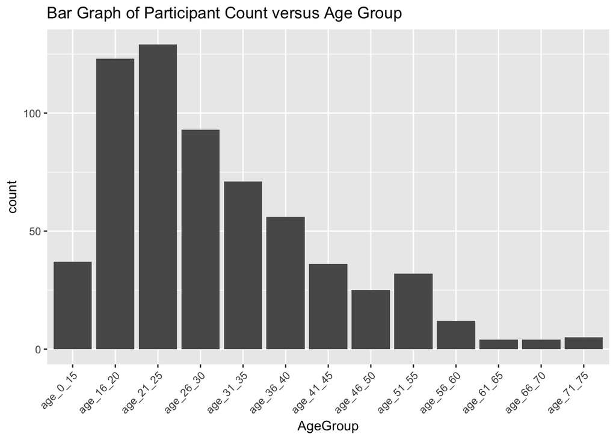

```r
bar1 <- ggplot(gvd_acs_age_long, aes(x=AgeGroup)) +
  geom_bar() +
  ggtitle("Bar Graph of Participant Count versus Age Group") +
  theme(axis.text.x = element_text(angle = 45, hjust = 1))
bar1
```

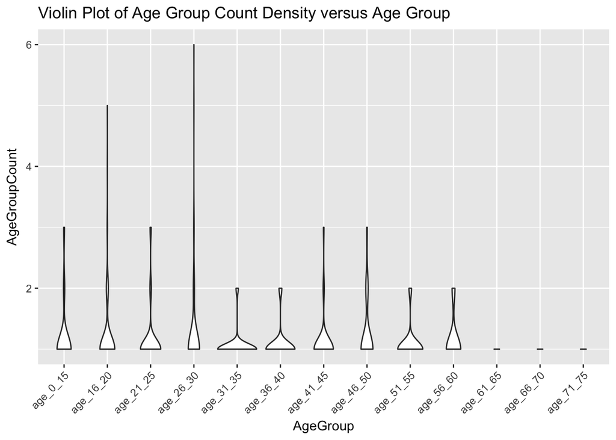

```r
violin1 <- ggplot(gvd_acs_age_long, aes(x=AgeGroup, y=AgeGroupCount)) +
  geom_violin() +
  ggtitle("Violin Plot of Age Group Count Density versus Age Group") +
  theme(axis.text.x = element_text(angle = 45, hjust = 1))
violin1
```

### Data Transformation

The latitude and longitude attributes were normalized from 0 till 1 and plotted with an xy scatter.

```r
range01 <- function(x){(x-min(x))/(max(x)-min(x))}
gvd_acs_join$latitude_norm <- range01(gvd_acs_join$latitude)
gvd_acs_join$longitude_norm <- range01(gvd_acs_join$longitude)
```

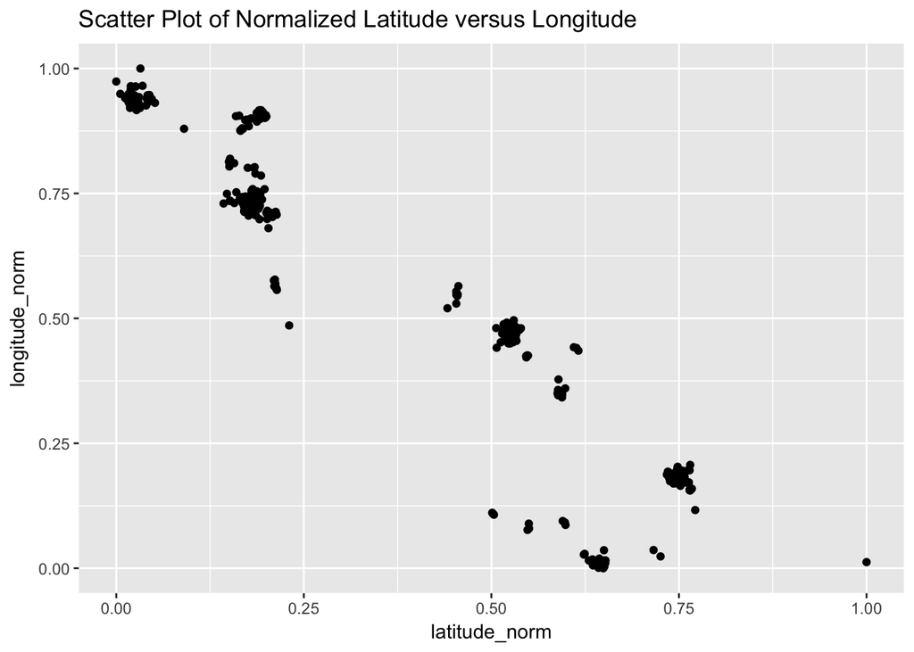

```r
scatter3 <- ggplot(gvd_acs_join, aes(latitude_norm, longitude_norm)) +
  geom_point(aes()) +
  ggtitle("Scatter Plot of Normalized Latitude versus Longitude")
scatter3
```

### Outliers

Outliers were detected using a boxplot of Income per capita.

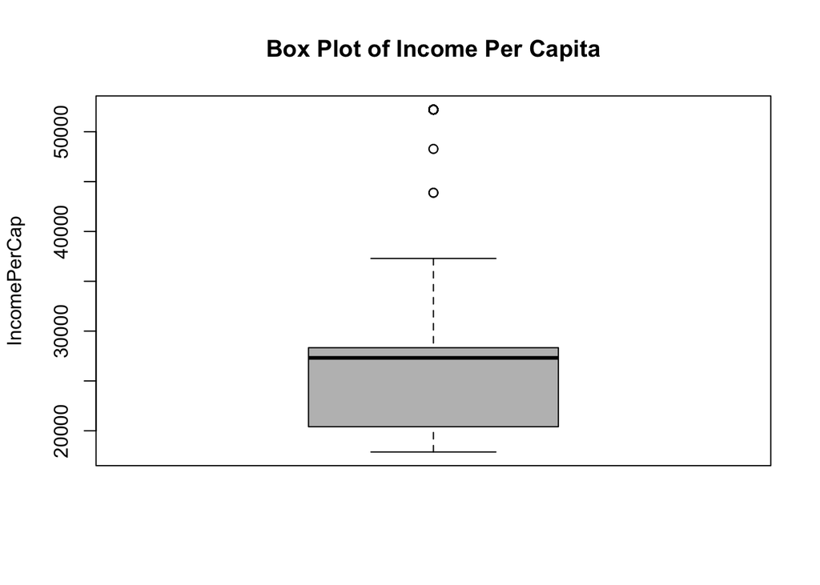

```r
gvd_acs_join$IncomePerCap %>%  boxplot(main="Box Plot of Income Per Capita", ylab="IncomePerCap", col = "grey")
```

```r
# Checking the summary stats
summary(gvd_acs_join$IncomePerCap)
```

```
##    Min. 1st Qu.  Median    Mean 3rd Qu.    Max.
##   17876   20408   27315   27079   28337   52220
```

```r
# Checking the z score summary stats
z.scores <- gvd_acs_join$IncomePerCap %>% scores(type = "z")
z.scores %>% summary()
```

```
##     Min.  1st Qu.   Median     Mean  3rd Qu.     Max.
## -1.08393 -0.78571  0.02783  0.00000  0.14820  2.96123
```

```r
# Checking the z score values
gvd_acs_join$IncomePerCap[which(abs(z.scores) > 3)]
```

```
## integer(0)
```

These values could not be classified as outliers according to the z-score method. Outliers were then checked for `gvd_acs_join$killed_count`. These outliers were also evaluated with the z-score method, and subsequently removed from the dataset.

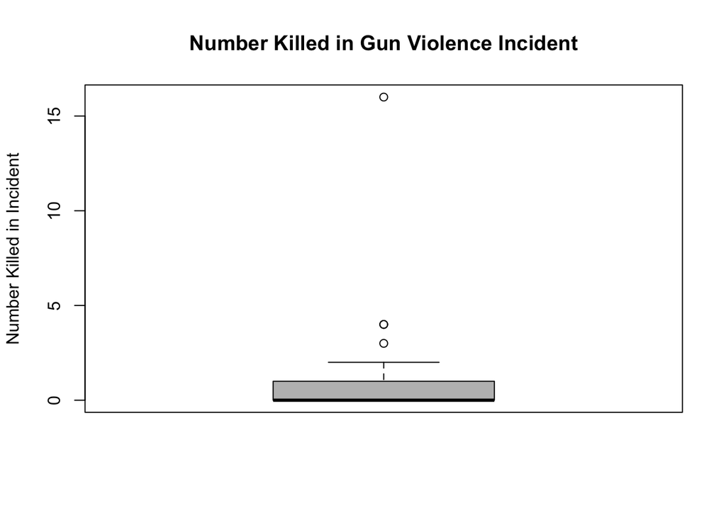

```r
gvd_acs_join$killed_count %>% boxplot(main="Number Killed in Gun Violence Incident", ylab="Number Killed in Incident", col = "grey")
```

```r
# Checking the summary stats
summary(gvd_acs_join$killed_count)
```

```
##    Min. 1st Qu.  Median    Mean 3rd Qu.    Max.
##  0.0000  0.0000  0.0000  0.3438  1.0000 16.0000
```

```r
# Checking the z score summary stats
z.scores <- gvd_acs_join$killed_count %>% scores(type = "z")
z.scores %>% summary()
```

```
##    Min. 1st Qu.  Median    Mean 3rd Qu.    Max.
## -0.4558 -0.4558 -0.4558  0.0000  0.8698 20.7551
```

```r
# Checking the z score values
gvd_acs_join$killed_count[which(abs(z.scores) > 3)]
```

```
## [1]  4  3 16  4
```

```r
# Imputing the outliers
killed_count_clean <- gvd_acs_join$killed_count[ - which(abs(z.scores) > 3)]
```

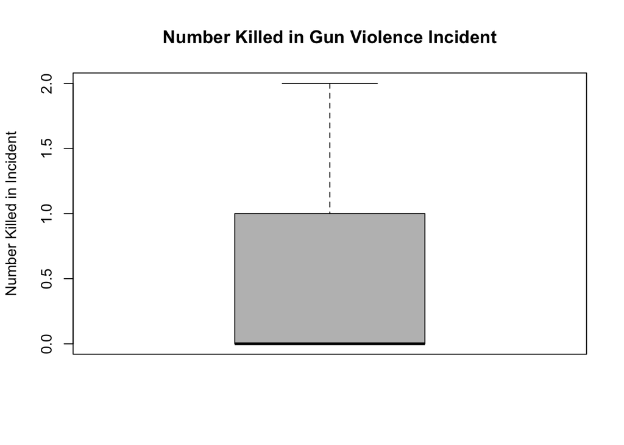

```r
killed_count_clean %>% boxplot(main="Number Killed in Gun Violence Incident", ylab="Number Killed in Incident", col = "grey")
```

### Other

The following scatter plot shows the relationship between income and unemployment, however could not be transformed with log10 as it contains bivariate data.

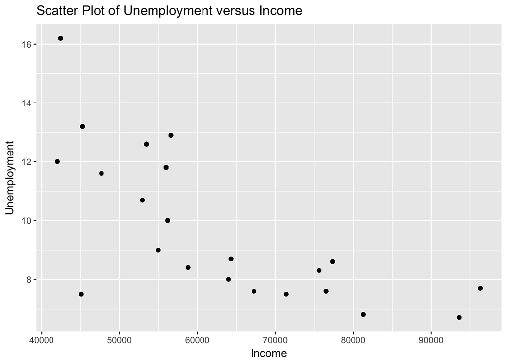

```r
scatter5 <- ggplot(gvd_acs_join, aes(Income, Unemployment)) +
  geom_point(aes()) +
  ggtitle("Scatter Plot of Unemployment versus Income")
scatter5
```

### References

[^1]: https://www.kaggle.com/jameslko/gun-violence-data/data
[^2]: https://www.kaggle.com/zimeiyang/2015-us-census-demographic-data/data